# IGN Data: Applying Statistics

by Ellen A. Savoye

Get going by asking the following questions and looking for the answers with some code and plots:

Can you count something interesting?

Can you find some trends (high, low, increase, decrease, anomalies)?

Can you make a bar plot or a histogram?

Can you compare two related quantities?

Can you make a scatterplot?

Can you make a time-series plot?

Having made these plots, what are some insights you get from them? Do you see any correlations? Is there a hypothesis you would like to investigate further? What other questions do they lead you to ask?

After cleaning up my dataset, I moved into applying some exploratory data analysis to unearth some inferences about the data.

```r
head(tbl_df(IGN_data), 5)
```

| X.1 | X | score_phrase | title | url | platform | score | genre | editors_choice | release_year | release_month | release_day | platform_group | genre_group |
| --- | --- | --- | --- | --- | --- | --- | --- | --- | --- | --- | --- | --- | --- |
| 1 | 0 | Amazing | LittleBigPlanet PS Vita | /games/littlebigplanet-vita/vita-98907 | PlayStation Vita | 9.0 | Platformer | Y | 2012 | 9 | 12 | PlayStation | Platformer |
| 2 | 1 | Amazing | LittleBigPlanet PS Vita -- Marvel Super Hero Edition | /games/littlebigplanet-ps-vita-marvel-super-hero-edition/vita-20027059 | PlayStation Vita | 9.0 | Platformer | Y | 2012 | 9 | 12 | PlayStation | Platformer |
| 3 | 2 | Great | Splice: Tree of Life | /games/splice/ipad-141070 | iPad | 8.5 | Puzzle | N | 2012 | 9 | 12 | Apple | Puzzle |
| 4 | 3 | Great | NHL 13 | /games/nhl-13/xbox-360-128182 | Xbox 360 | 8.5 | Sports | N | 2012 | 9 | 11 | Xbox | Sports |
| 5 | 4 | Great | NHL 13 | /games/nhl-13/ps3-128181 | PlayStation 3 | 8.5 | Sports | N | 2012 | 9 | 11 | PlayStation | Sports |

```r
top10 <- head(names((sort(table(IGN_data$genre_group), decreasing = TRUE))), 10)
```

The plots below are based on all 20 years worth of data. I knew the more positive the score phrase, the better the score. However, I wanted to plot see how far down an “Editor’s Choice” game would score. Based on the second graph below, the lowest is approximately an 8. However intersting this fact is, it only goes to show how large the score range is for an “Editor’s Choice” game can be.

```r
sort(unique(IGN_data$score_phrase))
```

```
##  [1] Amazing     Awful       Bad         Disaster    Good
##  [6] Great       Masterpiece Mediocre    Okay        Painful
## [11] Unbearable
## 11 Levels: Amazing Awful Bad Disaster Good Great Masterpiece ... Unbearable
```

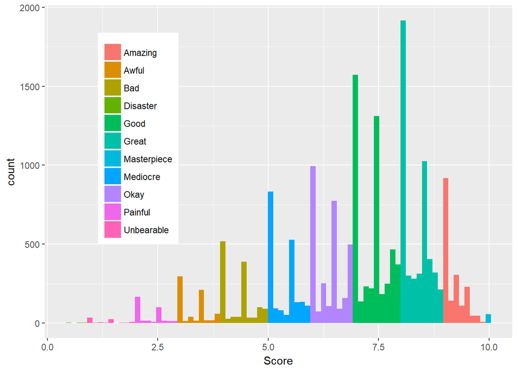

```r
#Score_vs_Phrase
ggplot(data=IGN_data, aes(score)) +
  geom_histogram(aes(fill=factor(score_phrase)),bins=80) +
  xlab('Score') +
  theme(legend.position=c(.2, .6)) +
  theme(legend.title=element_blank())
```

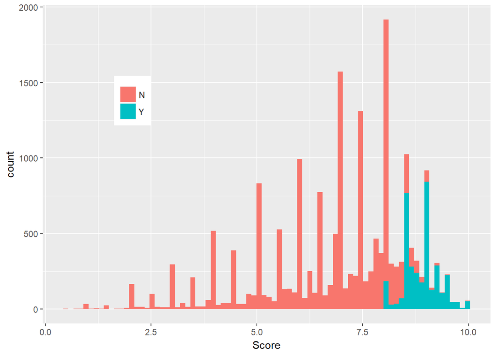

```r
#Score_vs_EdChc
ggplot(data=IGN_data, aes(score)) +
  geom_histogram(aes(fill=factor(editors_choice)),bins=80) +
  xlab('Score') + theme(legend.position=c(.2, .7)) +
  theme(legend.title=element_blank())
```

[figure not shown]

```r
#Score_vs_EdChc_vs_Yr
ggplot(data=IGN_data, aes(score)) +
  geom_histogram(aes(fill=factor(editors_choice)),bins=80) +
  xlab('Score') + theme(legend.position=c(.2, .7)) +
  theme(legend.title=element_blank()) +
  facet_grid(IGN_data$release_year ~ ., IGN_data$release_year > 2007)
```

```r
IGN_data %>%
  group_by(platform_group) %>%
  summarise(no_rows = length(platform_group)) %>%
  arrange(no_rows)
```

| platform_group | no_rows |
| --- | --- |
| WonderSwan | 5 |
| Linux | 11 |
| Android | 40 |
| NeoGeo | 41 |
| TurboGrafx | 43 |
| Atari | 89 |
| Sega | 381 |
| Other | 964 |
| Game Boy | 1001 |
| Apple | 1039 |

[output cut: 4 more lines]

[figure not shown]

```r
ggplot(IGN_data, aes(x = factor(release_year), y = score)) +
  geom_boxplot(aes(fill=(platform_group))) +
  theme(legend.position=c(.1, .2)) +
  xlab('Year') +
  ylab('Score') +
  theme(legend.title=element_blank()) +
  facet_grid(. ~ release_year)
```

The bar plot below serves two functions. The first is to see the magnitude of each genre. The second is to determine if there is a system that is more focused on releasing certain genres of games. Action, Sports, and Shooter games are the most popular. However, Nintendo has less presence in the Shooter game division. THe second graph below shows Platform versus year. 2008 was a very busy year. However, this can be accounted for as the year Ninentdo Wii came out.

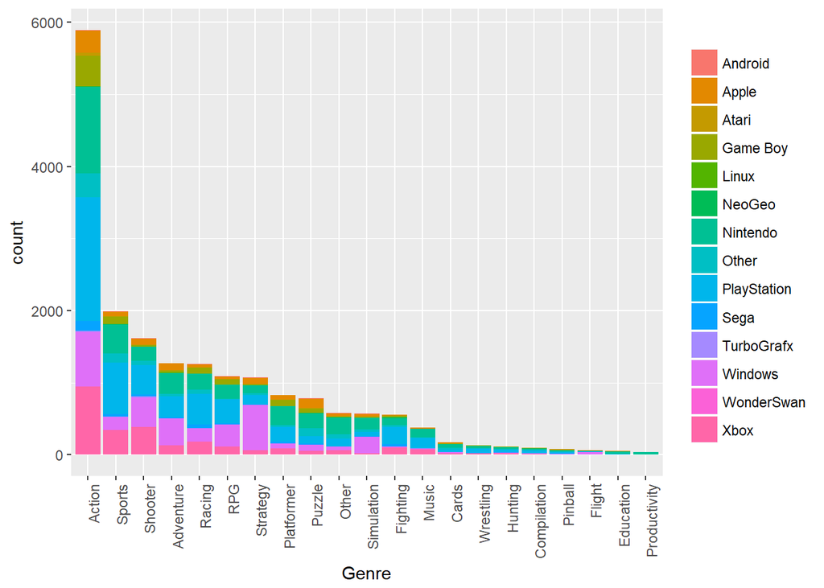

```r
#Platform vs Genre
ggplot(IGN_data, aes(x=reorder(genre_group,genre_group,function(x)-length(x)))) +
  geom_bar(aes(fill=platform_group)) +
  theme(axis.text.x = element_text(angle=90, hjust=1)) +
  xlab('Genre') + theme(legend.title=element_blank())
```

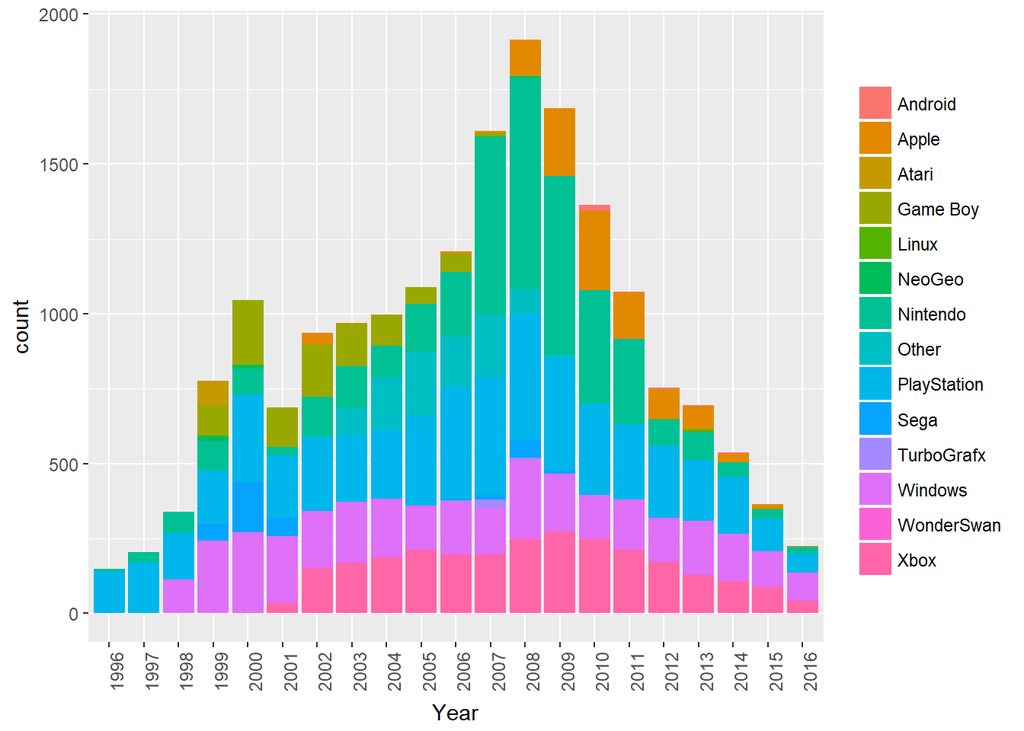

```r
#Platform vs Year
ggplot(IGN_data, aes(x=factor(release_year))) +
  geom_bar(aes(fill=platform_group)) +
  theme(axis.text.x = element_text(angle=90, hjust=1)) +
  xlab('Year') + theme(legend.title=element_blank())
```

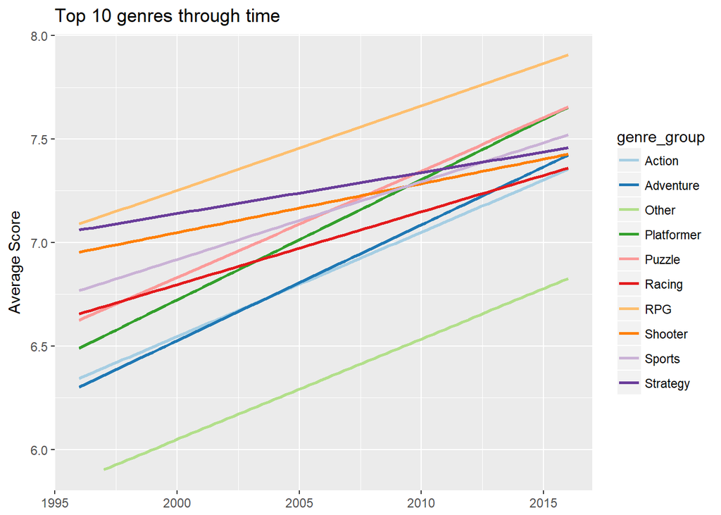

```r
IGN_data %>%
  filter(genre_group %in% top10) %>%
  group_by(genre_group, release_year) %>%
  summarize(average_score = mean(score, na.rm = TRUE)) %>%
  ggplot(aes(x = release_year, y = average_score, col = genre_group)) +
    geom_smooth(method = "lm", se = FALSE) +
    theme(axis.title.x = element_blank()) +
    labs(y = "Average Score", title = "Top 10 genres through time", x ="") +
    scale_color_brewer(palette = "Paired")
```

Count something interesting: # of editors choice games, score per genre,

Trends: day of week release, time of the year,

Having made these plots, what are some insights you get from them? Do you see any correlations? Is there a hypothesis you would like to investigate further? What other questions do they lead you to ask?